# WUP_04

Rashonda Weathersby

Feburary 2021

# Introduction

The data is in the file GSScsv.csv and came from the 2018 General Social Survey. The question to answer is to resolve this hypothesis.  
$H_0$ There is no difference between the average score on the WORDSUM test and level of schooling DEGREE  
$H_a$ There is a significant difference in average score on the WORDSUM test between at least two levels of DEGREE

# Results

## Descriptive Results

#### Using ggplot

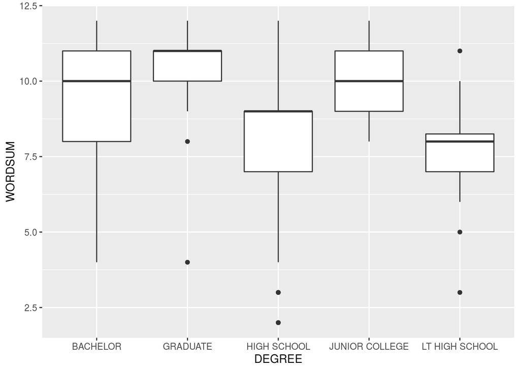

```r
basicCN <- ggplot(GSSdata,aes(x=DEGREE,y=WORDSUM))

basicCN + geom_boxplot()
```

According to the box plot people with LT high school degrees scored the lowest in the plot with dots outlines on the plot. According to the chart the students with Bachelors and Junior college degrees scored similar, as people with Graduates degrees on average scored the highest.

### Numerical Descriptive Results

```r
favstats(WORDSUM~DEGREE,data=GSSdata)
```

| DEGREE | min | Q1 | median | Q3 | max | mean | sd | n | missing |
| --- | --- | --- | --- | --- | --- | --- | --- | --- | --- |
| BACHELOR | 4 | 8 | 10 | 11.00 | 12 | 9.204545 | 2.052560 | 44 | 0 |
| GRADUATE | 4 | 10 | 11 | 11.00 | 12 | 10.095238 | 1.729299 | 21 | 0 |
| HIGH SCHOOL | 2 | 7 | 9 | 9.00 | 12 | 8.282353 | 2.234000 | 85 | 0 |
| JUNIOR COLLEGE | 8 | 9 | 10 | 11.00 | 12 | 9.916667 | 1.378954 | 12 | 0 |
| LT HIGH SCHOOL | 3 | 7 | 8 | 8.25 | 11 | 7.750000 | 1.949359 | 16 | 0 |

The numerical description shows that the Graduates median is at 11 which is the highest score.The Lt High School median is at an 8 which is the lowest of the group.

## Inferential Results

```r
model1 <- aov(WORDSUM~DEGREE,data=GSSdata)
summary.aov(model1)
```

```
##              Df Sum Sq Mean Sq F value   Pr(>F)
## DEGREE        4   97.8  24.445   5.729 0.000236 ***
## Residuals   173  738.1   4.267
## ---
## Signif. codes:  0 '***' 0.001 '**' 0.01 '*' 0.05 '.' 0.1 ' ' 1
```

```r
model1 <- aov(WORDSUM~DEGREE,data=GSSdata)
summary.aov(model1)
```

```
##              Df Sum Sq Mean Sq F value   Pr(>F)
## DEGREE        4   97.8  24.445   5.729 0.000236 ***
## Residuals   173  738.1   4.267
## ---
## Signif. codes:  0 '***' 0.001 '**' 0.01 '*' 0.05 '.' 0.1 ' ' 1
```

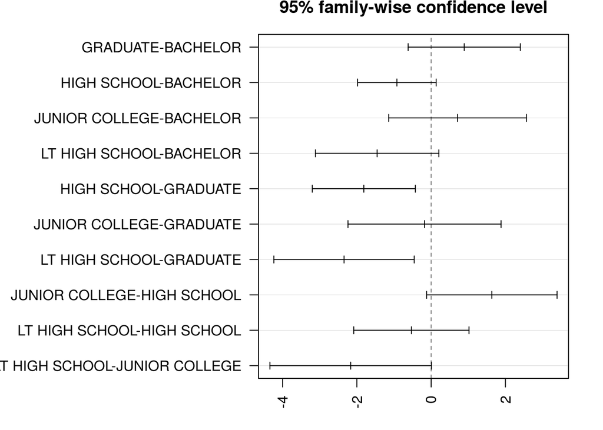

```r
par(mar= c(3, 15, 2, 2))
plot(TukeyHSD(model1),las=2)
```

# Discussion and Conclusion